# Integración

# Objetivo

Se utiliza en dataset de las ventas de asientos para bebes en automóviles. Se quiere predecir aquellos establecimientos que tienen una venta altas de dichos coches (High)

```r
library(tidyverse)
library(tidymodels)
library(workflows)
library(ISLR) #el dataset se encuentra en esta librería
library(rpart.plot)

data(Carseats)

glimpse(Carseats)
```

```
## Rows: 400
## Columns: 11
## $ Sales       <dbl> 9.50, 11.22, 10.06, 7.40, 4.15, 10.81, 6.63, 11.85, 6.54, ~
## $ CompPrice   <dbl> 138, 111, 113, 117, 141, 124, 115, 136, 132, 132, 121, 117~
## $ Income      <dbl> 73, 48, 35, 100, 64, 113, 105, 81, 110, 113, 78, 94, 35, 2~
## $ Advertising <dbl> 11, 16, 10, 4, 3, 13, 0, 15, 0, 0, 9, 4, 2, 11, 11, 5, 0, ~
## $ Population  <dbl> 276, 260, 269, 466, 340, 501, 45, 425, 108, 131, 150, 503,~
## $ Price       <dbl> 120, 83, 80, 97, 128, 72, 108, 120, 124, 124, 100, 94, 136~
## $ ShelveLoc   <fct> Bad, Good, Medium, Medium, Bad, Bad, Medium, Good, Medium,~
## $ Age         <dbl> 42, 65, 59, 55, 38, 78, 71, 67, 76, 76, 26, 50, 62, 53, 52~
## $ Education   <dbl> 17, 10, 12, 14, 13, 16, 15, 10, 10, 17, 10, 13, 18, 18, 18~
## $ Urban       <fct> Yes, Yes, Yes, Yes, Yes, No, Yes, Yes, No, No, No, Yes, Ye~
## $ US          <fct> Yes, Yes, Yes, Yes, No, Yes, No, Yes, No, Yes, Yes, Yes, N~
```

```r
Carseats <- as_tibble(Carseats) %>%
  mutate(High = factor(if_else(Sales <= 10, "No", "Yes")))

Carseats$Sales <-NULL
```

```r
Carseats$High <- relevel(Carseats$High, ref = "Yes")
levels(Carseats$High)
```

```
## [1] "Yes" "No"
```

# Análisis exploratorio

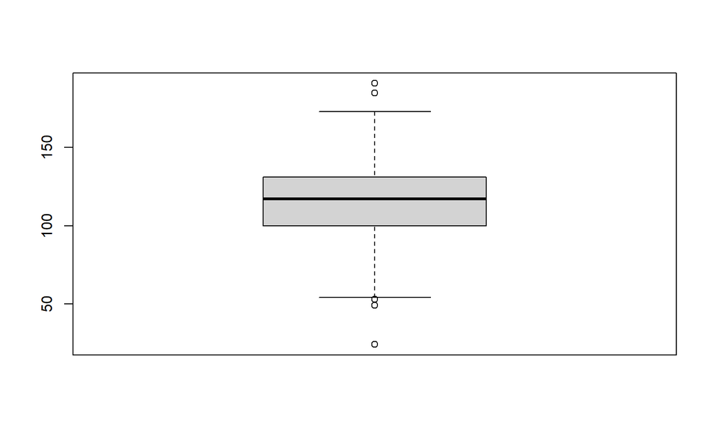

```r
boxplot(Carseats$Price)
```

¿Hay alguna variación en el precio respecto a si el local se localiza en una zona urbana o rural?

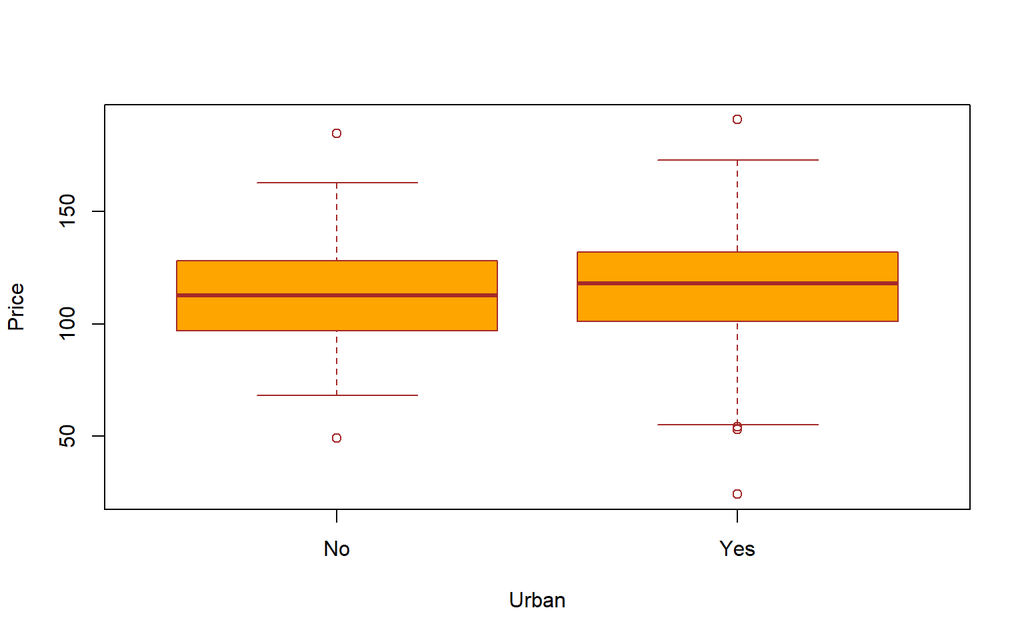

```r
boxplot(Price~Urban,
data=Carseats,
xlab="Urban",
ylab="Price",
col="orange",
border="brown"
)
```

¿Hay alguna relación entre la cantidad de ventas (variable High) y el precio de los asientos para autos para bebés?

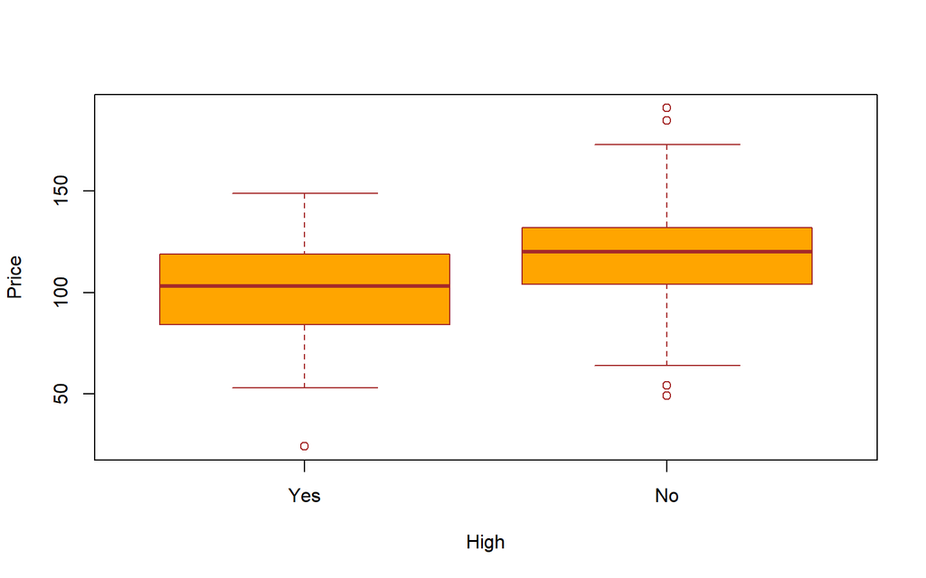

```r
boxplot(Price~High,
data=Carseats,
xlab="High",
ylab="Price",
col="orange",
border="brown"
)
```

¿Cómo es la distribución del promedio de edades de la población local de los establecimientos que venden los asientos para bebes?

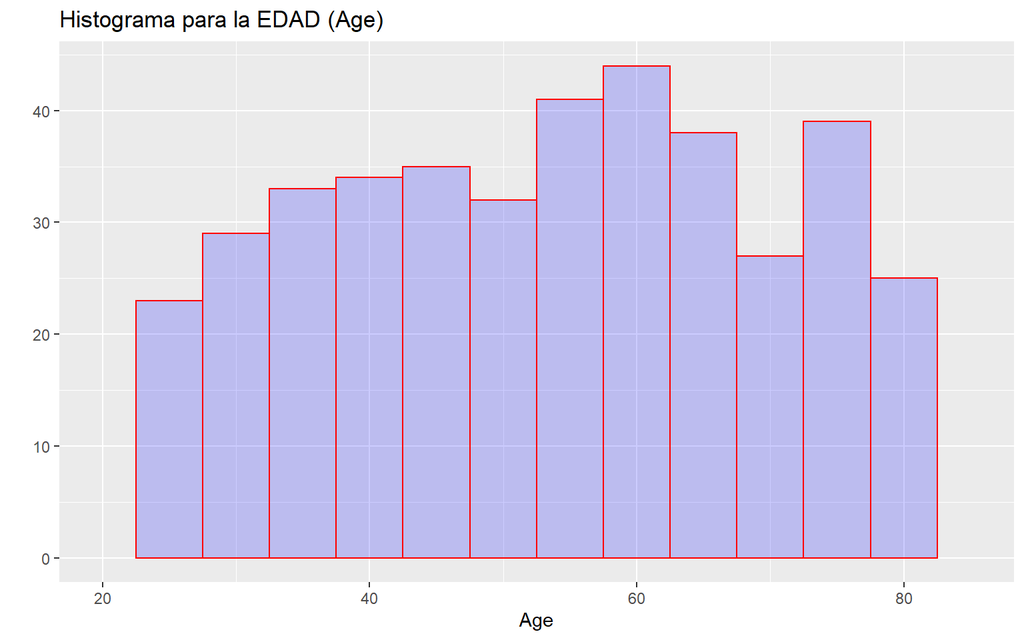

```r
qplot(Carseats$Age,
      geom="histogram",
      binwidth = 5,
      main = "Histograma para la EDAD (Age)",
      xlab = "Age",
      fill=I("blue"),
      col=I("red"),
      alpha=I(.2),
      xlim=c(20,85))
```

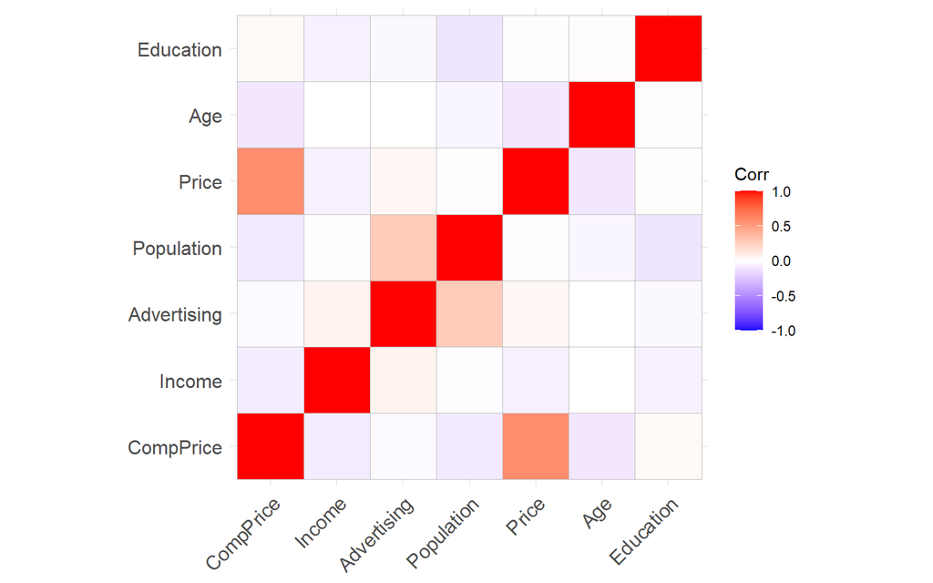

```r
library(ggcorrplot)

numericals <- select_if(Carseats, is.numeric)

### Correlation Matrix
cormat <- round(x = cor(numericals), digits = 2)
ggcorrplot::ggcorrplot(cor(numericals))
```

¿Hay desbalance en la variable respuesta?

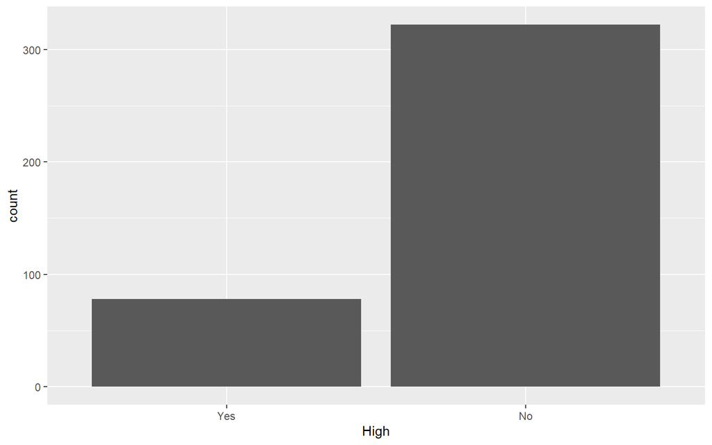

```r
g <- ggplot(Carseats, aes(High))
g + geom_bar()
```

## División del dataset: Entrenamiento y testeo

```r
set.seed(123)#setear la semilla

# Create data split for train and test
df_split <- initial_split(Carseats,
                          prop = 0.8,
                          strata = High)

# Create training data
df_train <- df_split %>%
              training()

# Create testing data
df_test <- df_split %>%
              testing()

# Number of rows in train and test dataset
paste0("Total del dataset de entrenamiento: ", nrow(df_train))
```

```
## [1] "Total del dataset de entrenamiento: 319"
```

```r
paste0("Total del dataset de testeo: ", nrow(df_test))
```

```
## [1] "Total del dataset de testeo: 81"
```

# Preprocesamiento de datos usando `recipe`

```r
library(themis)

recipe_df <-  recipe (High~ ., data= df_train) %>%
              step_corr(all_numeric_predictors()) %>%
              step_scale(all_numeric_predictors())%>%
              step_dummy(all_nominal_predictors(), -all_outcomes()) %>%
              step_upsample(High) %>%
              prep()
```

## Cross-validation

```r
set.seed(1234)

fold_df <- vfold_cv(df_train, v=3)
fold_df$splits
```

```
## [[1]]
## <Analysis/Assess/Total>
## <212/107/319>
##
## [[2]]
## <Analysis/Assess/Total>
## <213/106/319>
##
## [[3]]
## <Analysis/Assess/Total>
## <213/106/319>
```

# Especificando el modelo y tuneo de hiperparámetros

Recordemos:

1- Especificar el modelo (eg. Regresión logística, Random Forest, SVM, etc)

2- Con `set_engine()` se especifíca la familia de modelos

3- Con `set_mode()` se especifica el tipo de modelo a entrenarse (regresión o clasificación)

4- Usar la función `fit ()` para entrenar el modelo y, dentro de eso, debe proporcionar la notación de la fórmula y el conjunto de datos

Con `tune`, se especifica qué hiperparámetros van a ser tuneados.

```r
#Arboles de decisión
set.seed(234)
model_TREE <- decision_tree(tree_depth = tune(),  min_n = tune()) %>%
  set_engine("rpart") %>%
  set_mode("classification")
```

## Uniendo todo en un *Workflow*

```r
wf_TREE <- workflow() %>%
          add_recipe(recipe_df) %>%
          add_model(model_TREE)
```

Hiperparámetros

```r
param_grid <- grid_regular(tree_depth(), min_n(), levels = 3)
param_grid
```

```
## # A tibble: 9 x 2
##   tree_depth min_n
##        <int> <int>
## 1          1     2
## 2          8     2
## 3         15     2
## 4          1    21
## 5          8    21
## 6         15    21
## 7          1    40
## 8          8    40
## 9         15    40
```

## Entrenamiento

```r
doParallel::registerDoParallel() #paralelizamos los cálculos
set.seed(345)

tune_DF <- tune_grid(
  model_TREE,
  High~ .,
  resamples = fold_df,
  grid = param_grid,
  metrics = metric_set(accuracy, sensitivity, precision)
)

tune_DF
```

```
## # Tuning results
## # 3-fold cross-validation
## # A tibble: 3 x 4
##   splits            id    .metrics          .notes
##   <list>            <chr> <list>            <list>
## 1 <split [212/107]> Fold1 <tibble [27 x 6]> <tibble [0 x 1]>
## 2 <split [213/106]> Fold2 <tibble [27 x 6]> <tibble [0 x 1]>
## 3 <split [213/106]> Fold3 <tibble [27 x 6]> <tibble [1 x 1]>
```

Las métricas provienen del rendimiento de la validación cruzada a través de los diferentes valores de los parámetros.

```r
collect_metrics(tune_DF)
```

```
## # A tibble: 27 x 8
##    tree_depth min_n .metric   .estimator  mean     n std_err .config
##         <int> <int> <chr>     <chr>      <dbl> <int>   <dbl> <chr>
##  1          1     2 accuracy  binary     0.799     3  0.0177 Preprocessor1_Mode~
##  2          1     2 precision binary     0.482     2  0.0593 Preprocessor1_Mode~
##  3          1     2 sens      binary     0.436     3  0.219  Preprocessor1_Mode~
##  4          8     2 accuracy  binary     0.802     3  0.0251 Preprocessor1_Mode~
##  5          8     2 precision binary     0.529     3  0.129  Preprocessor1_Mode~
##  6          8     2 sens      binary     0.477     3  0.0429 Preprocessor1_Mode~
##  7         15     2 accuracy  binary     0.802     3  0.0251 Preprocessor1_Mode~
##  8         15     2 precision binary     0.529     3  0.129  Preprocessor1_Mode~
##  9         15     2 sens      binary     0.477     3  0.0429 Preprocessor1_Mode~
## 10          1    21 accuracy  binary     0.799     3  0.0177 Preprocessor1_Mode~
## # ... with 17 more rows
```

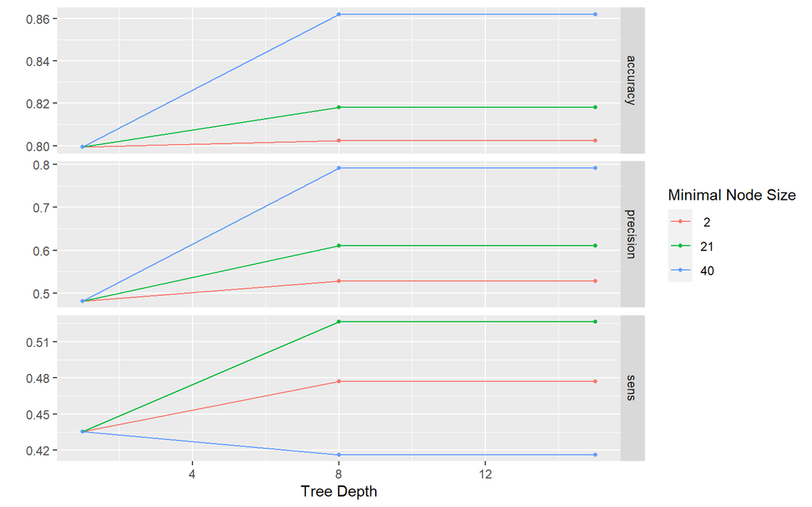

```r
autoplot(tune_DF)
```

## Selección del mejor modelo

```r
param_final <- tune_DF %>%
  select_best(metric = "precision")
param_final
```

```
## # A tibble: 1 x 3
##   tree_depth min_n .config
##        <int> <int> <chr>
## 1          8    40 Preprocessor1_Model8
```

```r
wf_TREE <- wf_TREE %>%
  finalize_workflow(param_final)
```

```r
tree_final_fit <- fit(wf_TREE, data= df_train)
tree_final_fit
```

```
## == Workflow [trained] ==========================================================
## Preprocessor: Recipe
## Model: decision_tree()
##
## -- Preprocessor ----------------------------------------------------------------
## 4 Recipe Steps
##
## * step_corr()
## * step_scale()
## * step_dummy()
## * step_upsample()
##
## -- Model -----------------------------------------------------------------------
## n= 514
##
## node), split, n, loss, yval, (yprob)
##       * denotes terminal node
##
##   1) root 514 257 Yes (0.50000000 0.50000000)
##     2) Price< 4.00932 140  32 Yes (0.77142857 0.22857143)
##       4) CompPrice>=7.994161 67   5 Yes (0.92537313 0.07462687) *
##       5) CompPrice< 7.994161 73  27 Yes (0.63013699 0.36986301)
##        10) Price< 3.669907 54  13 Yes (0.75925926 0.24074074) *
##        11) Price>=3.669907 19   5 No (0.26315789 0.73684211) *
##     3) Price>=4.00932 374 149 No (0.39839572 0.60160428)
##       6) Advertising>=0.07596529 279 137 Yes (0.50896057 0.49103943)
##        12) Age< 3.872622 223  89 Yes (0.60089686 0.39910314)
##          24) Price< 5.918521 202  68 Yes (0.66336634 0.33663366)
##            48) Income>=1.819444 148  35 Yes (0.76351351 0.23648649)
##              96) CompPrice>=9.254651 42   2 Yes (0.95238095 0.04761905) *
##              97) CompPrice< 9.254651 106  33 Yes (0.68867925 0.31132075)
##               194) Advertising>=0.9115834 92  23 Yes (0.75000000 0.25000000) *
##               195) Advertising< 0.9115834 14   4 No (0.28571429 0.71428571) *
##            49) Income< 1.819444 54  21 No (0.38888889 0.61111111)
##              98) Age< 1.951802 14   3 Yes (0.78571429 0.21428571) *
##              99) Age>=1.951802 40  10 No (0.25000000 0.75000000)
##               198) CompPrice>=8.79026 17   7 Yes (0.58823529 0.41176471) *
##               199) CompPrice< 8.79026 23   0 No (0.00000000 1.00000000) *
##          25) Price>=5.918521 21   0 No (0.00000000 1.00000000) *
##        13) Age>=3.872622 56   8 No (0.14285714 0.85714286) *
##       7) Advertising< 0.07596529 95   7 No (0.07368421 0.92631579) *
```

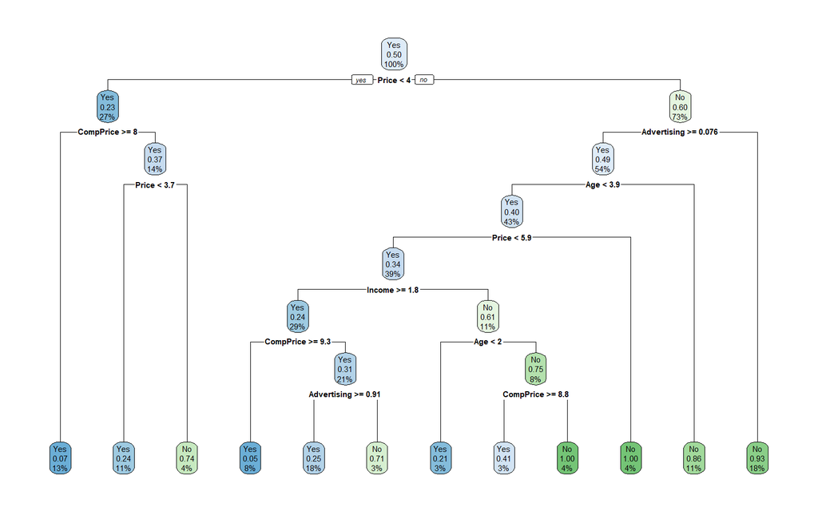

```r
tree_final_fit %>% extract_fit_engine() %>%
  rpart.plot()
```

# Evaluación en test

```r
rf_fit <- wf_TREE %>%
  # fit on the training set and evaluate on test set
  last_fit(df_split)

rf_fit
```

```
## # Resampling results
## # Manual resampling
## # A tibble: 1 x 6
##   splits           id               .metrics   .notes    .predictions  .workflow
##   <list>           <chr>            <list>     <list>    <list>        <list>
## 1 <split [319/81]> train/test split <tibble [~ <tibble ~ <tibble [81 ~ <workflo~
```

```r
test_performance <- rf_fit %>% collect_metrics()
test_performance
```

```
## # A tibble: 2 x 4
##   .metric  .estimator .estimate .config
##   <chr>    <chr>          <dbl> <chr>
## 1 accuracy binary         0.704 Preprocessor1_Model1
## 2 roc_auc  binary         0.751 Preprocessor1_Model1
```

```r
# generate predictions from the test set
test_predictions <- rf_fit %>% collect_predictions()
test_predictions
```

```
## # A tibble: 81 x 7
##    id               .pred_Yes .pred_No  .row .pred_class High  .config
##    <chr>                <dbl>    <dbl> <int> <fct>       <fct> <chr>
##  1 train/test split     0.759   0.241      2 Yes         Yes   Preprocessor1_Mo~
##  2 train/test split     0.759   0.241      3 Yes         Yes   Preprocessor1_Mo~
##  3 train/test split     0.952   0.0476     5 Yes         No    Preprocessor1_Mo~
##  4 train/test split     0.143   0.857      8 No          Yes   Preprocessor1_Mo~
##  5 train/test split     0.263   0.737     12 No          Yes   Preprocessor1_Mo~
##  6 train/test split     0.286   0.714     21 No          No    Preprocessor1_Mo~
##  7 train/test split     0.952   0.0476    25 Yes         Yes   Preprocessor1_Mo~
##  8 train/test split     0.75    0.25      27 Yes         No    Preprocessor1_Mo~
##  9 train/test split     0.75    0.25      32 Yes         No    Preprocessor1_Mo~
## 10 train/test split     0.75    0.25      36 Yes         Yes   Preprocessor1_Mo~
## # ... with 71 more rows
```

## Matriz de confusion

```r
collect_predictions(rf_fit) %>%
  conf_mat(High, .pred_class)
```

```
##           Truth
## Prediction Yes No
##        Yes  11 19
##        No    5 46
```

```r
collect_predictions(rf_fit) %>%
  precision(High, .pred_class)
```

```
## # A tibble: 1 x 3
##   .metric   .estimator .estimate
##   <chr>     <chr>          <dbl>
## 1 precision binary         0.367
```

## Importancia de las variables

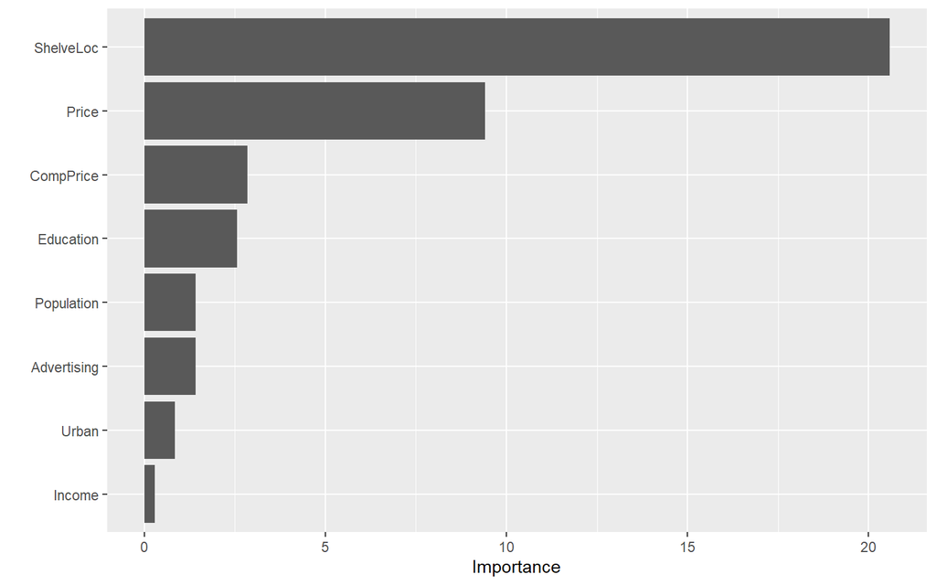

```r
library(vip)

final <- decision_tree(tree_depth = 8, min_n = 40) %>%
  set_engine("rpart") %>%
  set_mode("classification")

final_fit <- fit(final, High ~ ., data = df_train)
vip(final_fit)
```